# Risk Factor Analysis

## Outcome Variable

**Outcome Variable:** ever_co

## Predictor Variables

**Intervention Variable:** sex

**Adjustment Set:**

unadjusted

## Stratifying Variables

The analysis was stratified on these variable(s):

- agecat
- studyid
- country

## Data Summary

| agecat | studyid | country | sex | ever_co | n_cell | n |
| --- | --- | --- | --- | --- | --- | --- |
| 0-24 months | ki0047075b-MAL-ED | BANGLADESH | Female | 0 | 115 | 263 |
| 0-24 months | ki0047075b-MAL-ED | BANGLADESH | Female | 1 | 19 | 263 |
| 0-24 months | ki0047075b-MAL-ED | BANGLADESH | Male | 0 | 109 | 263 |
| 0-24 months | ki0047075b-MAL-ED | BANGLADESH | Male | 1 | 20 | 263 |
| 0-24 months | ki0047075b-MAL-ED | BRAZIL | Female | 0 | 113 | 233 |
| 0-24 months | ki0047075b-MAL-ED | BRAZIL | Female | 1 | 0 | 233 |
| 0-24 months | ki0047075b-MAL-ED | BRAZIL | Male | 0 | 118 | 233 |
| 0-24 months | ki0047075b-MAL-ED | BRAZIL | Male | 1 | 2 | 233 |
| 0-24 months | ki0047075b-MAL-ED | INDIA | Female | 0 | 113 | 251 |
| 0-24 months | ki0047075b-MAL-ED | INDIA | Female | 1 | 25 | 251 |
| 0-24 months | ki0047075b-MAL-ED | INDIA | Male | 0 | 84 | 251 |
| 0-24 months | ki0047075b-MAL-ED | INDIA | Male | 1 | 29 | 251 |
| 0-24 months | ki0047075b-MAL-ED | NEPAL | Female | 0 | 99 | 240 |
| 0-24 months | ki0047075b-MAL-ED | NEPAL | Female | 1 | 11 | 240 |
| 0-24 months | ki0047075b-MAL-ED | NEPAL | Male | 0 | 120 | 240 |
| 0-24 months | ki0047075b-MAL-ED | NEPAL | Male | 1 | 10 | 240 |
| 0-24 months | ki0047075b-MAL-ED | PERU | Female | 0 | 138 | 302 |
| 0-24 months | ki0047075b-MAL-ED | PERU | Female | 1 | 4 | 302 |
| 0-24 months | ki0047075b-MAL-ED | PERU | Male | 0 | 152 | 302 |
| 0-24 months | ki0047075b-MAL-ED | PERU | Male | 1 | 8 | 302 |
| 0-24 months | ki0047075b-MAL-ED | SOUTH AFRICA | Female | 0 | 150 | 312 |
| 0-24 months | ki0047075b-MAL-ED | SOUTH AFRICA | Female | 1 | 8 | 312 |
| 0-24 months | ki0047075b-MAL-ED | SOUTH AFRICA | Male | 0 | 140 | 312 |
| 0-24 months | ki0047075b-MAL-ED | SOUTH AFRICA | Male | 1 | 14 | 312 |
| 0-24 months | ki0047075b-MAL-ED | TANZANIA, UNITED REPUBLIC OF | Female | 0 | 120 | 261 |
| 0-24 months | ki0047075b-MAL-ED | TANZANIA, UNITED REPUBLIC OF | Female | 1 | 12 | 261 |
| 0-24 months | ki0047075b-MAL-ED | TANZANIA, UNITED REPUBLIC OF | Male | 0 | 118 | 261 |
| 0-24 months | ki0047075b-MAL-ED | TANZANIA, UNITED REPUBLIC OF | Male | 1 | 11 | 261 |
| 0-24 months | ki1000108-CMC-V-BCS-2002 | INDIA | Female | 0 | 157 | 373 |
| 0-24 months | ki1000108-CMC-V-BCS-2002 | INDIA | Female | 1 | 30 | 373 |

[output cut: 374 more lines]

The following strata were considered:

- agecat: 0-24 months, studyid: ki0047075b-MAL-ED, country: BANGLADESH
- agecat: 0-24 months, studyid: ki0047075b-MAL-ED, country: BRAZIL
- agecat: 0-24 months, studyid: ki0047075b-MAL-ED, country: INDIA
- agecat: 0-24 months, studyid: ki0047075b-MAL-ED, country: NEPAL
- agecat: 0-24 months, studyid: ki0047075b-MAL-ED, country: PERU
- agecat: 0-24 months, studyid: ki0047075b-MAL-ED, country: SOUTH AFRICA
- agecat: 0-24 months, studyid: ki0047075b-MAL-ED, country: TANZANIA, UNITED REPUBLIC OF
- agecat: 0-24 months, studyid: ki1000108-CMC-V-BCS-2002, country: INDIA
- agecat: 0-24 months, studyid: ki1000108-IRC, country: INDIA
- agecat: 0-24 months, studyid: ki1000109-EE, country: PAKISTAN
- agecat: 0-24 months, studyid: ki1000109-ResPak, country: PAKISTAN
- agecat: 0-24 months, studyid: ki1000304b-SAS-CompFeed, country: INDIA
- agecat: 0-24 months, studyid: ki1000304b-SAS-FoodSuppl, country: INDIA
- agecat: 0-24 months, studyid: ki1017093-NIH-Birth, country: BANGLADESH
- agecat: 0-24 months, studyid: ki1017093b-PROVIDE, country: BANGLADESH
- agecat: 0-24 months, studyid: ki1017093c-NIH-Crypto, country: BANGLADESH
- agecat: 0-24 months, studyid: ki1066203-TanzaniaChild2, country: TANZANIA, UNITED REPUBLIC OF
- agecat: 0-24 months, studyid: ki1101329-Keneba, country: GAMBIA
- agecat: 0-24 months, studyid: ki1112895-Guatemala BSC, country: GUATEMALA
- agecat: 0-24 months, studyid: ki1112895-iLiNS-Zinc, country: BURKINA FASO
- agecat: 0-24 months, studyid: ki1113344-GMS-Nepal, country: NEPAL
- agecat: 0-24 months, studyid: ki1114097-CMIN, country: BANGLADESH
- agecat: 0-24 months, studyid: ki1114097-CMIN, country: BRAZIL
- agecat: 0-24 months, studyid: ki1114097-CMIN, country: GUINEA-BISSAU
- agecat: 0-24 months, studyid: ki1114097-CMIN, country: PERU
- agecat: 0-24 months, studyid: ki1114097-CONTENT, country: PERU
- agecat: 0-24 months, studyid: ki1119695-PROBIT, country: BELARUS
- agecat: 0-24 months, studyid: ki1126311-ZVITAMBO, country: ZIMBABWE
- agecat: 0-24 months, studyid: ki1135781-COHORTS, country: GUATEMALA
- agecat: 0-24 months, studyid: ki1135781-COHORTS, country: INDIA
- agecat: 0-24 months, studyid: ki1135781-COHORTS, country: PHILIPPINES
- agecat: 0-24 months, studyid: ki1148112-LCNI-5, country: MALAWI
- agecat: 0-24 months, studyid: kiGH5241-JiVitA-3, country: BANGLADESH
- agecat: 0-24 months, studyid: kiGH5241-JiVitA-4, country: BANGLADESH
- agecat: 0-6 months, studyid: ki0047075b-MAL-ED, country: BANGLADESH
- agecat: 0-6 months, studyid: ki0047075b-MAL-ED, country: BRAZIL
- agecat: 0-6 months, studyid: ki0047075b-MAL-ED, country: INDIA
- agecat: 0-6 months, studyid: ki0047075b-MAL-ED, country: NEPAL
- agecat: 0-6 months, studyid: ki0047075b-MAL-ED, country: PERU
- agecat: 0-6 months, studyid: ki0047075b-MAL-ED, country: SOUTH AFRICA
- agecat: 0-6 months, studyid: ki0047075b-MAL-ED, country: TANZANIA, UNITED REPUBLIC OF
- agecat: 0-6 months, studyid: ki1000108-CMC-V-BCS-2002, country: INDIA
- agecat: 0-6 months, studyid: ki1000108-IRC, country: INDIA
- agecat: 0-6 months, studyid: ki1000109-EE, country: PAKISTAN
- agecat: 0-6 months, studyid: ki1000109-ResPak, country: PAKISTAN
- agecat: 0-6 months, studyid: ki1000304b-SAS-CompFeed, country: INDIA
- agecat: 0-6 months, studyid: ki1000304b-SAS-FoodSuppl, country: INDIA
- agecat: 0-6 months, studyid: ki1017093-NIH-Birth, country: BANGLADESH
- agecat: 0-6 months, studyid: ki1017093b-PROVIDE, country: BANGLADESH
- agecat: 0-6 months, studyid: ki1017093c-NIH-Crypto, country: BANGLADESH
- agecat: 0-6 months, studyid: ki1066203-TanzaniaChild2, country: TANZANIA, UNITED REPUBLIC OF
- agecat: 0-6 months, studyid: ki1101329-Keneba, country: GAMBIA
- agecat: 0-6 months, studyid: ki1112895-Guatemala BSC, country: GUATEMALA
- agecat: 0-6 months, studyid: ki1113344-GMS-Nepal, country: NEPAL
- agecat: 0-6 months, studyid: ki1114097-CMIN, country: BANGLADESH
- agecat: 0-6 months, studyid: ki1114097-CMIN, country: BRAZIL
- agecat: 0-6 months, studyid: ki1114097-CMIN, country: GUINEA-BISSAU
- agecat: 0-6 months, studyid: ki1114097-CMIN, country: PERU
- agecat: 0-6 months, studyid: ki1114097-CONTENT, country: PERU
- agecat: 0-6 months, studyid: ki1119695-PROBIT, country: BELARUS
- agecat: 0-6 months, studyid: ki1126311-ZVITAMBO, country: ZIMBABWE
- agecat: 0-6 months, studyid: ki1135781-COHORTS, country: GUATEMALA
- agecat: 0-6 months, studyid: ki1135781-COHORTS, country: INDIA
- agecat: 0-6 months, studyid: ki1135781-COHORTS, country: PHILIPPINES
- agecat: 0-6 months, studyid: ki1148112-LCNI-5, country: MALAWI
- agecat: 0-6 months, studyid: kiGH5241-JiVitA-3, country: BANGLADESH
- agecat: 0-6 months, studyid: kiGH5241-JiVitA-4, country: BANGLADESH
- agecat: 6-24 months, studyid: ki0047075b-MAL-ED, country: BANGLADESH
- agecat: 6-24 months, studyid: ki0047075b-MAL-ED, country: BRAZIL
- agecat: 6-24 months, studyid: ki0047075b-MAL-ED, country: INDIA
- agecat: 6-24 months, studyid: ki0047075b-MAL-ED, country: NEPAL
- agecat: 6-24 months, studyid: ki0047075b-MAL-ED, country: PERU
- agecat: 6-24 months, studyid: ki0047075b-MAL-ED, country: SOUTH AFRICA
- agecat: 6-24 months, studyid: ki0047075b-MAL-ED, country: TANZANIA, UNITED REPUBLIC OF
- agecat: 6-24 months, studyid: ki1000108-CMC-V-BCS-2002, country: INDIA
- agecat: 6-24 months, studyid: ki1000108-IRC, country: INDIA
- agecat: 6-24 months, studyid: ki1000109-EE, country: PAKISTAN
- agecat: 6-24 months, studyid: ki1000109-ResPak, country: PAKISTAN
- agecat: 6-24 months, studyid: ki1000304b-SAS-CompFeed, country: INDIA
- agecat: 6-24 months, studyid: ki1000304b-SAS-FoodSuppl, country: INDIA
- agecat: 6-24 months, studyid: ki1017093-NIH-Birth, country: BANGLADESH
- agecat: 6-24 months, studyid: ki1017093b-PROVIDE, country: BANGLADESH
- agecat: 6-24 months, studyid: ki1017093c-NIH-Crypto, country: BANGLADESH
- agecat: 6-24 months, studyid: ki1066203-TanzaniaChild2, country: TANZANIA, UNITED REPUBLIC OF
- agecat: 6-24 months, studyid: ki1101329-Keneba, country: GAMBIA
- agecat: 6-24 months, studyid: ki1112895-Guatemala BSC, country: GUATEMALA
- agecat: 6-24 months, studyid: ki1112895-iLiNS-Zinc, country: BURKINA FASO
- agecat: 6-24 months, studyid: ki1113344-GMS-Nepal, country: NEPAL
- agecat: 6-24 months, studyid: ki1114097-CMIN, country: BANGLADESH
- agecat: 6-24 months, studyid: ki1114097-CMIN, country: BRAZIL
- agecat: 6-24 months, studyid: ki1114097-CMIN, country: GUINEA-BISSAU
- agecat: 6-24 months, studyid: ki1114097-CMIN, country: PERU
- agecat: 6-24 months, studyid: ki1114097-CONTENT, country: PERU
- agecat: 6-24 months, studyid: ki1119695-PROBIT, country: BELARUS
- agecat: 6-24 months, studyid: ki1126311-ZVITAMBO, country: ZIMBABWE
- agecat: 6-24 months, studyid: ki1135781-COHORTS, country: GUATEMALA
- agecat: 6-24 months, studyid: ki1135781-COHORTS, country: INDIA
- agecat: 6-24 months, studyid: ki1135781-COHORTS, country: PHILIPPINES
- agecat: 6-24 months, studyid: ki1148112-LCNI-5, country: MALAWI
- agecat: 6-24 months, studyid: kiGH5241-JiVitA-3, country: BANGLADESH
- agecat: 6-24 months, studyid: kiGH5241-JiVitA-4, country: BANGLADESH

### Dropped Strata

Some strata were dropped due to rare outcomes:

- agecat: 0-24 months, studyid: ki0047075b-MAL-ED, country: BRAZIL
- agecat: 0-24 months, studyid: ki0047075b-MAL-ED, country: PERU
- agecat: 0-24 months, studyid: ki1114097-CMIN, country: BRAZIL
- agecat: 0-24 months, studyid: ki1114097-CONTENT, country: PERU
- agecat: 0-24 months, studyid: ki1119695-PROBIT, country: BELARUS
- agecat: 0-6 months, studyid: ki0047075b-MAL-ED, country: BANGLADESH
- agecat: 0-6 months, studyid: ki0047075b-MAL-ED, country: BRAZIL
- agecat: 0-6 months, studyid: ki0047075b-MAL-ED, country: NEPAL
- agecat: 0-6 months, studyid: ki0047075b-MAL-ED, country: PERU
- agecat: 0-6 months, studyid: ki0047075b-MAL-ED, country: SOUTH AFRICA
- agecat: 0-6 months, studyid: ki0047075b-MAL-ED, country: TANZANIA, UNITED REPUBLIC OF
- agecat: 0-6 months, studyid: ki1066203-TanzaniaChild2, country: TANZANIA, UNITED REPUBLIC OF
- agecat: 0-6 months, studyid: ki1112895-Guatemala BSC, country: GUATEMALA
- agecat: 0-6 months, studyid: ki1114097-CMIN, country: BRAZIL
- agecat: 0-6 months, studyid: ki1114097-CMIN, country: GUINEA-BISSAU
- agecat: 0-6 months, studyid: ki1114097-CONTENT, country: PERU
- agecat: 0-6 months, studyid: ki1119695-PROBIT, country: BELARUS
- agecat: 0-6 months, studyid: ki1135781-COHORTS, country: GUATEMALA
- agecat: 0-6 months, studyid: ki1148112-LCNI-5, country: MALAWI
- agecat: 6-24 months, studyid: ki0047075b-MAL-ED, country: BRAZIL
- agecat: 6-24 months, studyid: ki0047075b-MAL-ED, country: PERU
- agecat: 6-24 months, studyid: ki1114097-CMIN, country: BRAZIL
- agecat: 6-24 months, studyid: ki1114097-CONTENT, country: PERU
- agecat: 6-24 months, studyid: ki1119695-PROBIT, country: BELARUS

## Methods Detail

We’re interested in the causal parameters $E[Y_a]$ for all values of $a \in \mathcal{A}$. These parameters represent the mean outcome if, possibly contrary to fact, we intervened to set all units to have $A=a$. Under the randomization and positivity assumptions, these are identified by the statistical parameters $\psi_a=E_W[E_{Y|A,W}(Y|A=a,W)]$. In addition, we’re interested in the mean of $Y$, $E[Y]$ under no intervention (the observed mean). We will estimate these parameters by using SuperLearner to fit the relevant likelihood factors – $E_{Y|A,W}(Y|A=a,W)$ and $p(A=a|W)$, and then updating our likelihood fit using a joint TMLE.

For unadjusted analyses ($W=\{\}$), initial likelihoods were estimated using Lrnr_glm to estimate the simple $E(Y|A)$ and Lrnr_mean to estimate $p(A)$. For adjusted analyses, a small library containing Lrnr_glmnet, Lrnr_xgboost, and Lrnr_mean was used.

Having estimated these parameters, we will then use the delta method to estimate relative risks and attributable risks relative to a prespecified baseline level of $A$.

# Results Detail

## Results Plots

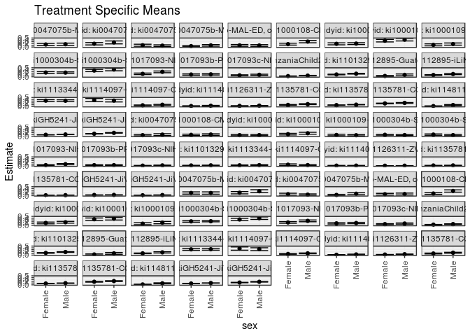

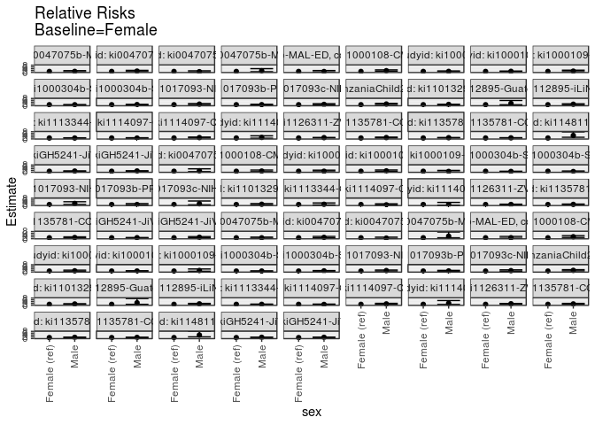

[figure not shown]

[figure not shown]

## Results Table

### Parameter: TSM

| agecat | studyid | country | intervention_level | baseline_level | estimate | ci_lower | ci_upper |
| --- | --- | --- | --- | --- | --- | --- | --- |
| 0-24 months | ki0047075b-MAL-ED | BANGLADESH | Female | NA | 0.1417910 | 0.0826153 | 0.2009668 |
| 0-24 months | ki0047075b-MAL-ED | BANGLADESH | Male | NA | 0.1550388 | 0.0924611 | 0.2176164 |
| 0-24 months | ki0047075b-MAL-ED | INDIA | Female | NA | 0.1811594 | 0.1167713 | 0.2455475 |
| 0-24 months | ki0047075b-MAL-ED | INDIA | Male | NA | 0.2566372 | 0.1759442 | 0.3373302 |
| 0-24 months | ki0047075b-MAL-ED | NEPAL | Female | NA | 0.1000000 | 0.0438203 | 0.1561797 |
| 0-24 months | ki0047075b-MAL-ED | NEPAL | Male | NA | 0.0769231 | 0.0310212 | 0.1228249 |
| 0-24 months | ki0047075b-MAL-ED | SOUTH AFRICA | Female | NA | 0.0506329 | 0.0163916 | 0.0848742 |
| 0-24 months | ki0047075b-MAL-ED | SOUTH AFRICA | Male | NA | 0.0909091 | 0.0454321 | 0.1363861 |
| 0-24 months | ki0047075b-MAL-ED | TANZANIA, UNITED REPUBLIC OF | Female | NA | 0.0909091 | 0.0417728 | 0.1400453 |
| 0-24 months | ki0047075b-MAL-ED | TANZANIA, UNITED REPUBLIC OF | Male | NA | 0.0852713 | 0.0369838 | 0.1335588 |
| 0-24 months | ki1000108-CMC-V-BCS-2002 | INDIA | Female | NA | 0.1604278 | 0.1077559 | 0.2130997 |
| 0-24 months | ki1000108-CMC-V-BCS-2002 | INDIA | Male | NA | 0.3010753 | 0.2350626 | 0.3670879 |
| 0-24 months | ki1000108-IRC | INDIA | Female | NA | 0.1783784 | 0.1231453 | 0.2336115 |
| 0-24 months | ki1000108-IRC | INDIA | Male | NA | 0.1911111 | 0.1396742 | 0.2425480 |
| 0-24 months | ki1000109-EE | PAKISTAN | Female | NA | 0.3513514 | 0.2824684 | 0.4202343 |
| 0-24 months | ki1000109-EE | PAKISTAN | Male | NA | 0.4072165 | 0.3379885 | 0.4764445 |
| 0-24 months | ki1000109-ResPak | PAKISTAN | Female | NA | 0.1212121 | 0.0654347 | 0.1769896 |
| 0-24 months | ki1000109-ResPak | PAKISTAN | Male | NA | 0.1643836 | 0.1041572 | 0.2246100 |
| 0-24 months | ki1000304b-SAS-CompFeed | INDIA | Female | NA | 0.2346939 | 0.1859778 | 0.2834100 |
| 0-24 months | ki1000304b-SAS-CompFeed | INDIA | Male | NA | 0.2297461 | 0.1908675 | 0.2686246 |
| 0-24 months | ki1000304b-SAS-FoodSuppl | INDIA | Female | NA | 0.3452915 | 0.2828127 | 0.4077703 |
| 0-24 months | ki1000304b-SAS-FoodSuppl | INDIA | Male | NA | 0.4000000 | 0.3311575 | 0.4688425 |
| 0-24 months | ki1017093-NIH-Birth | BANGLADESH | Female | NA | 0.1621622 | 0.1201374 | 0.2041869 |
| 0-24 months | ki1017093-NIH-Birth | BANGLADESH | Male | NA | 0.2713415 | 0.2231822 | 0.3195007 |
| 0-24 months | ki1017093b-PROVIDE | BANGLADESH | Female | NA | 0.1234940 | 0.0880788 | 0.1589092 |
| 0-24 months | ki1017093b-PROVIDE | BANGLADESH | Male | NA | 0.1331522 | 0.0984161 | 0.1678882 |
| 0-24 months | ki1017093c-NIH-Crypto | BANGLADESH | Female | NA | 0.0787402 | 0.0516781 | 0.1058023 |
| 0-24 months | ki1017093c-NIH-Crypto | BANGLADESH | Male | NA | 0.1087533 | 0.0773059 | 0.1402007 |
| 0-24 months | ki1066203-TanzaniaChild2 | TANZANIA, UNITED REPUBLIC OF | Female | NA | 0.0354730 | 0.0249347 | 0.0460112 |
| 0-24 months | ki1066203-TanzaniaChild2 | TANZANIA, UNITED REPUBLIC OF | Male | NA | 0.0635314 | 0.0497964 | 0.0772663 |

[output cut: 124 more lines]

### Parameter: E(Y)

| agecat | studyid | country | intervention_level | baseline_level | estimate | ci_lower | ci_upper |
| --- | --- | --- | --- | --- | --- | --- | --- |
| 0-24 months | ki0047075b-MAL-ED | BANGLADESH | NA | NA | 0.1482890 | 0.1052563 | 0.1913216 |
| 0-24 months | ki0047075b-MAL-ED | INDIA | NA | NA | 0.2151394 | 0.1642023 | 0.2660766 |
| 0-24 months | ki0047075b-MAL-ED | NEPAL | NA | NA | 0.0875000 | 0.0516764 | 0.1233236 |
| 0-24 months | ki0047075b-MAL-ED | SOUTH AFRICA | NA | NA | 0.0705128 | 0.0420601 | 0.0989655 |
| 0-24 months | ki0047075b-MAL-ED | TANZANIA, UNITED REPUBLIC OF | NA | NA | 0.0881226 | 0.0536659 | 0.1225793 |
| 0-24 months | ki1000108-CMC-V-BCS-2002 | INDIA | NA | NA | 0.2305630 | 0.1877616 | 0.2733644 |
| 0-24 months | ki1000108-IRC | INDIA | NA | NA | 0.1853659 | 0.1477057 | 0.2230261 |
| 0-24 months | ki1000109-EE | PAKISTAN | NA | NA | 0.3799472 | 0.3310169 | 0.4288776 |
| 0-24 months | ki1000109-ResPak | PAKISTAN | NA | NA | 0.1438849 | 0.1025533 | 0.1852165 |
| 0-24 months | ki1000304b-SAS-CompFeed | INDIA | NA | NA | 0.2319894 | 0.1917264 | 0.2722524 |
| 0-24 months | ki1000304b-SAS-FoodSuppl | INDIA | NA | NA | 0.3708134 | 0.3244530 | 0.4171738 |
| 0-24 months | ki1017093-NIH-Birth | BANGLADESH | NA | NA | 0.2195513 | 0.1870467 | 0.2520558 |
| 0-24 months | ki1017093b-PROVIDE | BANGLADESH | NA | NA | 0.1285714 | 0.1037574 | 0.1533855 |
| 0-24 months | ki1017093c-NIH-Crypto | BANGLADESH | NA | NA | 0.0936675 | 0.0729118 | 0.1144233 |
| 0-24 months | ki1066203-TanzaniaChild2 | TANZANIA, UNITED REPUBLIC OF | NA | NA | 0.0496661 | 0.0409652 | 0.0583670 |
| 0-24 months | ki1101329-Keneba | GAMBIA | NA | NA | 0.1483516 | 0.1354394 | 0.1612639 |
| 0-24 months | ki1112895-Guatemala BSC | GUATEMALA | NA | NA | 0.0730159 | 0.0442400 | 0.1017917 |
| 0-24 months | ki1112895-iLiNS-Zinc | BURKINA FASO | NA | NA | 0.1246554 | 0.1041227 | 0.1451882 |
| 0-24 months | ki1113344-GMS-Nepal | NEPAL | NA | NA | 0.3205980 | 0.2832855 | 0.3579105 |
| 0-24 months | ki1114097-CMIN | BANGLADESH | NA | NA | 0.3394834 | 0.2830004 | 0.3959663 |
| 0-24 months | ki1114097-CMIN | GUINEA-BISSAU | NA | NA | 0.0809555 | 0.0671794 | 0.0947317 |
| 0-24 months | ki1114097-CMIN | PERU | NA | NA | 0.0333692 | 0.0218140 | 0.0449244 |
| 0-24 months | ki1126311-ZVITAMBO | ZIMBABWE | NA | NA | 0.0417653 | 0.0384437 | 0.0450870 |
| 0-24 months | ki1135781-COHORTS | GUATEMALA | NA | NA | 0.1104522 | 0.0937191 | 0.1271852 |
| 0-24 months | ki1135781-COHORTS | INDIA | NA | NA | 0.0894353 | 0.0829338 | 0.0959368 |
| 0-24 months | ki1135781-COHORTS | PHILIPPINES | NA | NA | 0.1839080 | 0.1701456 | 0.1976705 |
| 0-24 months | ki1148112-LCNI-5 | MALAWI | NA | NA | 0.0511905 | 0.0362780 | 0.0661030 |
| 0-24 months | kiGH5241-JiVitA-3 | BANGLADESH | NA | NA | 0.0885357 | 0.0846606 | 0.0924107 |
| 0-24 months | kiGH5241-JiVitA-4 | BANGLADESH | NA | NA | 0.1613377 | 0.1500062 | 0.1726692 |
| 0-6 months | ki0047075b-MAL-ED | INDIA | NA | NA | 0.0717131 | 0.0397302 | 0.1036961 |
| 0-6 months | ki1000108-CMC-V-BCS-2002 | INDIA | NA | NA | 0.0842391 | 0.0558231 | 0.1126551 |
| 0-6 months | ki1000108-IRC | INDIA | NA | NA | 0.0611247 | 0.0378797 | 0.0843697 |
| 0-6 months | ki1000109-EE | PAKISTAN | NA | NA | 0.1398417 | 0.1048786 | 0.1748048 |
| 0-6 months | ki1000109-ResPak | PAKISTAN | NA | NA | 0.0611511 | 0.0329343 | 0.0893679 |
| 0-6 months | ki1000304b-SAS-CompFeed | INDIA | NA | NA | 0.0704787 | 0.0478990 | 0.0930584 |
| 0-6 months | ki1000304b-SAS-FoodSuppl | INDIA | NA | NA | 0.0769231 | 0.0512858 | 0.1025603 |
| 0-6 months | ki1017093-NIH-Birth | BANGLADESH | NA | NA | 0.0723473 | 0.0519719 | 0.0927227 |
| 0-6 months | ki1017093b-PROVIDE | BANGLADESH | NA | NA | 0.0428571 | 0.0278427 | 0.0578716 |
| 0-6 months | ki1017093c-NIH-Crypto | BANGLADESH | NA | NA | 0.0224274 | 0.0118796 | 0.0329753 |
| 0-6 months | ki1101329-Keneba | GAMBIA | NA | NA | 0.0287711 | 0.0221274 | 0.0354147 |
| 0-6 months | ki1113344-GMS-Nepal | NEPAL | NA | NA | 0.0398671 | 0.0242254 | 0.0555088 |
| 0-6 months | ki1114097-CMIN | BANGLADESH | NA | NA | 0.0553506 | 0.0280757 | 0.0826254 |
| 0-6 months | ki1114097-CMIN | PERU | NA | NA | 0.0157368 | 0.0065040 | 0.0249696 |
| 0-6 months | ki1126311-ZVITAMBO | ZIMBABWE | NA | NA | 0.0120665 | 0.0102474 | 0.0138855 |
| 0-6 months | ki1135781-COHORTS | INDIA | NA | NA | 0.0259576 | 0.0222658 | 0.0296495 |
| 0-6 months | ki1135781-COHORTS | PHILIPPINES | NA | NA | 0.0236531 | 0.0182537 | 0.0290525 |
| 0-6 months | kiGH5241-JiVitA-3 | BANGLADESH | NA | NA | 0.0393736 | 0.0368903 | 0.0418569 |
| 0-6 months | kiGH5241-JiVitA-4 | BANGLADESH | NA | NA | 0.0265122 | 0.0211694 | 0.0318550 |
| 6-24 months | ki0047075b-MAL-ED | BANGLADESH | NA | NA | 0.1464435 | 0.1015265 | 0.1913605 |
| 6-24 months | ki0047075b-MAL-ED | INDIA | NA | NA | 0.2000000 | 0.1487493 | 0.2512507 |
| 6-24 months | ki0047075b-MAL-ED | NEPAL | NA | NA | 0.0680851 | 0.0358110 | 0.1003592 |
| 6-24 months | ki0047075b-MAL-ED | SOUTH AFRICA | NA | NA | 0.0733591 | 0.0415449 | 0.1051733 |
| 6-24 months | ki0047075b-MAL-ED | TANZANIA, UNITED REPUBLIC OF | NA | NA | 0.0857143 | 0.0505889 | 0.1208396 |
| 6-24 months | ki1000108-CMC-V-BCS-2002 | INDIA | NA | NA | 0.1876676 | 0.1479906 | 0.2273445 |
| 6-24 months | ki1000108-IRC | INDIA | NA | NA | 0.1560976 | 0.1209228 | 0.1912723 |
| 6-24 months | ki1000109-EE | PAKISTAN | NA | NA | 0.3538874 | 0.3052956 | 0.4024792 |
| 6-24 months | ki1000109-ResPak | PAKISTAN | NA | NA | 0.1260870 | 0.0830938 | 0.1690801 |
| 6-24 months | ki1000304b-SAS-CompFeed | INDIA | NA | NA | 0.2260619 | 0.1909133 | 0.2612105 |
| 6-24 months | ki1000304b-SAS-FoodSuppl | INDIA | NA | NA | 0.3615960 | 0.3145115 | 0.4086805 |
| 6-24 months | ki1017093-NIH-Birth | BANGLADESH | NA | NA | 0.2103321 | 0.1759902 | 0.2446740 |
| 6-24 months | ki1017093b-PROVIDE | BANGLADESH | NA | NA | 0.1221498 | 0.0962275 | 0.1480722 |
| 6-24 months | ki1017093c-NIH-Crypto | BANGLADESH | NA | NA | 0.0863014 | 0.0659171 | 0.1066856 |
| 6-24 months | ki1066203-TanzaniaChild2 | TANZANIA, UNITED REPUBLIC OF | NA | NA | 0.0560238 | 0.0459853 | 0.0660623 |
| 6-24 months | ki1101329-Keneba | GAMBIA | NA | NA | 0.1469835 | 0.1337108 | 0.1602563 |
| 6-24 months | ki1112895-Guatemala BSC | GUATEMALA | NA | NA | 0.0649819 | 0.0359016 | 0.0940623 |
| 6-24 months | ki1112895-iLiNS-Zinc | BURKINA FASO | NA | NA | 0.1246554 | 0.1041227 | 0.1451882 |
| 6-24 months | ki1113344-GMS-Nepal | NEPAL | NA | NA | 0.3220339 | 0.2842988 | 0.3597690 |
| 6-24 months | ki1114097-CMIN | BANGLADESH | NA | NA | 0.3426295 | 0.2837999 | 0.4014590 |
| 6-24 months | ki1114097-CMIN | GUINEA-BISSAU | NA | NA | 0.0803511 | 0.0665019 | 0.0942003 |
| 6-24 months | ki1114097-CMIN | PERU | NA | NA | 0.0273349 | 0.0165432 | 0.0381265 |
| 6-24 months | ki1126311-ZVITAMBO | ZIMBABWE | NA | NA | 0.0406808 | 0.0369363 | 0.0444253 |
| 6-24 months | ki1135781-COHORTS | GUATEMALA | NA | NA | 0.1116585 | 0.0939639 | 0.1293530 |
| 6-24 months | ki1135781-COHORTS | INDIA | NA | NA | 0.0831652 | 0.0766672 | 0.0896632 |
| 6-24 months | ki1135781-COHORTS | PHILIPPINES | NA | NA | 0.1908832 | 0.1763448 | 0.2054216 |
| 6-24 months | ki1148112-LCNI-5 | MALAWI | NA | NA | 0.0520581 | 0.0368996 | 0.0672166 |
| 6-24 months | kiGH5241-JiVitA-3 | BANGLADESH | NA | NA | 0.0869213 | 0.0822621 | 0.0915805 |
| 6-24 months | kiGH5241-JiVitA-4 | BANGLADESH | NA | NA | 0.1477252 | 0.1371297 | 0.1583206 |

### Parameter: RR

| agecat | studyid | country | intervention_level | baseline_level | estimate | ci_lower | ci_upper |
| --- | --- | --- | --- | --- | --- | --- | --- |
| 0-24 months | ki0047075b-MAL-ED | BANGLADESH | Female | Female | 1.0000000 | 1.0000000 | 1.000000 |
| 0-24 months | ki0047075b-MAL-ED | BANGLADESH | Male | Female | 1.0934313 | 0.6118463 | 1.954072 |
| 0-24 months | ki0047075b-MAL-ED | INDIA | Female | Female | 1.0000000 | 1.0000000 | 1.000000 |
| 0-24 months | ki0047075b-MAL-ED | INDIA | Male | Female | 1.4166372 | 0.8813913 | 2.276924 |
| 0-24 months | ki0047075b-MAL-ED | NEPAL | Female | Female | 1.0000000 | 1.0000000 | 1.000000 |
| 0-24 months | ki0047075b-MAL-ED | NEPAL | Male | Female | 0.7692308 | 0.3389391 | 1.745789 |
| 0-24 months | ki0047075b-MAL-ED | SOUTH AFRICA | Female | Female | 1.0000000 | 1.0000000 | 1.000000 |
| 0-24 months | ki0047075b-MAL-ED | SOUTH AFRICA | Male | Female | 1.7954545 | 0.7742031 | 4.163839 |
| 0-24 months | ki0047075b-MAL-ED | TANZANIA, UNITED REPUBLIC OF | Female | Female | 1.0000000 | 1.0000000 | 1.000000 |
| 0-24 months | ki0047075b-MAL-ED | TANZANIA, UNITED REPUBLIC OF | Male | Female | 0.9379845 | 0.4287655 | 2.051972 |
| 0-24 months | ki1000108-CMC-V-BCS-2002 | INDIA | Female | Female | 1.0000000 | 1.0000000 | 1.000000 |
| 0-24 months | ki1000108-CMC-V-BCS-2002 | INDIA | Male | Female | 1.8767025 | 1.2645477 | 2.785195 |
| 0-24 months | ki1000108-IRC | INDIA | Female | Female | 1.0000000 | 1.0000000 | 1.000000 |
| 0-24 months | ki1000108-IRC | INDIA | Male | Female | 1.0713805 | 0.7108340 | 1.614802 |
| 0-24 months | ki1000109-EE | PAKISTAN | Female | Female | 1.0000000 | 1.0000000 | 1.000000 |
| 0-24 months | ki1000109-EE | PAKISTAN | Male | Female | 1.1590008 | 0.8941017 | 1.502383 |
| 0-24 months | ki1000109-ResPak | PAKISTAN | Female | Female | 1.0000000 | 1.0000000 | 1.000000 |
| 0-24 months | ki1000109-ResPak | PAKISTAN | Male | Female | 1.3561644 | 0.7531108 | 2.442113 |
| 0-24 months | ki1000304b-SAS-CompFeed | INDIA | Female | Female | 1.0000000 | 1.0000000 | 1.000000 |
| 0-24 months | ki1000304b-SAS-CompFeed | INDIA | Male | Female | 0.9789180 | 0.8472717 | 1.131019 |
| 0-24 months | ki1000304b-SAS-FoodSuppl | INDIA | Female | Female | 1.0000000 | 1.0000000 | 1.000000 |
| 0-24 months | ki1000304b-SAS-FoodSuppl | INDIA | Male | Female | 1.1584416 | 0.9024450 | 1.487057 |
| 0-24 months | ki1017093-NIH-Birth | BANGLADESH | Female | Female | 1.0000000 | 1.0000000 | 1.000000 |
| 0-24 months | ki1017093-NIH-Birth | BANGLADESH | Male | Female | 1.6732724 | 1.2222302 | 2.290764 |
| 0-24 months | ki1017093b-PROVIDE | BANGLADESH | Female | Female | 1.0000000 | 1.0000000 | 1.000000 |
| 0-24 months | ki1017093b-PROVIDE | BANGLADESH | Male | Female | 1.0782078 | 0.7317029 | 1.588804 |
| 0-24 months | ki1017093c-NIH-Crypto | BANGLADESH | Female | Female | 1.0000000 | 1.0000000 | 1.000000 |
| 0-24 months | ki1017093c-NIH-Crypto | BANGLADESH | Male | Female | 1.3811671 | 0.8814189 | 2.164263 |
| 0-24 months | ki1066203-TanzaniaChild2 | TANZANIA, UNITED REPUBLIC OF | Female | Female | 1.0000000 | 1.0000000 | 1.000000 |
| 0-24 months | ki1066203-TanzaniaChild2 | TANZANIA, UNITED REPUBLIC OF | Male | Female | 1.7909791 | 1.2402912 | 2.586172 |

[output cut: 124 more lines]

### Parameter: PAR

| agecat | studyid | country | intervention_level | baseline_level | estimate | ci_lower | ci_upper |
| --- | --- | --- | --- | --- | --- | --- | --- |
| 0-24 months | ki0047075b-MAL-ED | BANGLADESH | Female | NA | 0.0064979 | -0.0357541 | 0.0487500 |
| 0-24 months | ki0047075b-MAL-ED | INDIA | Female | NA | 0.0339800 | -0.0127282 | 0.0806883 |
| 0-24 months | ki0047075b-MAL-ED | NEPAL | Female | NA | -0.0125000 | -0.0518236 | 0.0268236 |
| 0-24 months | ki0047075b-MAL-ED | SOUTH AFRICA | Female | NA | 0.0198799 | -0.0083074 | 0.0480672 |
| 0-24 months | ki0047075b-MAL-ED | TANZANIA, UNITED REPUBLIC OF | Female | NA | -0.0027865 | -0.0368381 | 0.0312651 |
| 0-24 months | ki1000108-CMC-V-BCS-2002 | INDIA | Female | NA | 0.0701352 | 0.0274208 | 0.1128496 |
| 0-24 months | ki1000108-IRC | INDIA | Female | NA | 0.0069875 | -0.0344362 | 0.0484111 |
| 0-24 months | ki1000109-EE | PAKISTAN | Female | NA | 0.0285959 | -0.0214726 | 0.0786644 |
| 0-24 months | ki1000109-ResPak | PAKISTAN | Female | NA | 0.0226728 | -0.0205126 | 0.0658581 |
| 0-24 months | ki1000304b-SAS-CompFeed | INDIA | Female | NA | -0.0027045 | -0.0211624 | 0.0157535 |
| 0-24 months | ki1000304b-SAS-FoodSuppl | INDIA | Female | NA | 0.0255219 | -0.0179270 | 0.0689708 |
| 0-24 months | ki1017093-NIH-Birth | BANGLADESH | Female | NA | 0.0573891 | 0.0235200 | 0.0912582 |
| 0-24 months | ki1017093b-PROVIDE | BANGLADESH | Female | NA | 0.0050775 | -0.0210040 | 0.0311589 |
| 0-24 months | ki1017093c-NIH-Crypto | BANGLADESH | Female | NA | 0.0149274 | -0.0057351 | 0.0355898 |
| 0-24 months | ki1066203-TanzaniaChild2 | TANZANIA, UNITED REPUBLIC OF | Female | NA | 0.0141931 | 0.0054180 | 0.0229683 |
| 0-24 months | ki1101329-Keneba | GAMBIA | Female | NA | 0.0223730 | 0.0090585 | 0.0356875 |
| 0-24 months | ki1112895-Guatemala BSC | GUATEMALA | Female | NA | 0.0298060 | 0.0015226 | 0.0580894 |
| 0-24 months | ki1112895-iLiNS-Zinc | BURKINA FASO | Female | NA | 0.0274247 | 0.0094190 | 0.0454303 |
| 0-24 months | ki1113344-GMS-Nepal | NEPAL | Female | NA | -0.0023187 | -0.0412852 | 0.0366478 |
| 0-24 months | ki1114097-CMIN | BANGLADESH | Female | NA | -0.0164488 | -0.0809294 | 0.0480318 |
| 0-24 months | ki1114097-CMIN | GUINEA-BISSAU | Female | NA | 0.0149925 | 0.0012842 | 0.0287007 |
| 0-24 months | ki1114097-CMIN | PERU | Female | NA | 0.0085944 | -0.0033537 | 0.0205426 |
| 0-24 months | ki1126311-ZVITAMBO | ZIMBABWE | Female | NA | 0.0070482 | 0.0036460 | 0.0104505 |
| 0-24 months | ki1135781-COHORTS | GUATEMALA | Female | NA | 0.0222632 | 0.0046989 | 0.0398275 |
| 0-24 months | ki1135781-COHORTS | INDIA | Female | NA | 0.0130757 | 0.0063374 | 0.0198141 |
| 0-24 months | ki1135781-COHORTS | PHILIPPINES | Female | NA | 0.0154943 | 0.0009339 | 0.0300548 |
| 0-24 months | ki1148112-LCNI-5 | MALAWI | Female | NA | 0.0298128 | 0.0149155 | 0.0447101 |
| 0-24 months | kiGH5241-JiVitA-3 | BANGLADESH | Female | NA | 0.0095306 | 0.0060061 | 0.0130551 |
| 0-24 months | kiGH5241-JiVitA-4 | BANGLADESH | Female | NA | 0.0240397 | 0.0132862 | 0.0347931 |
| 0-6 months | ki0047075b-MAL-ED | INDIA | Female | NA | 0.0137421 | -0.0157688 | 0.0432530 |
| 0-6 months | ki1000108-CMC-V-BCS-2002 | INDIA | Female | NA | 0.0085635 | -0.0197129 | 0.0368398 |
| 0-6 months | ki1000108-IRC | INDIA | Female | NA | 0.0013421 | -0.0243144 | 0.0269986 |
| 0-6 months | ki1000109-EE | PAKISTAN | Female | NA | 0.0263282 | -0.0093393 | 0.0619956 |
| 0-6 months | ki1000109-ResPak | PAKISTAN | Female | NA | -0.0070307 | -0.0368575 | 0.0227960 |
| 0-6 months | ki1000304b-SAS-CompFeed | INDIA | Female | NA | -0.0085842 | -0.0195386 | 0.0023702 |
| 0-6 months | ki1000304b-SAS-FoodSuppl | INDIA | Female | NA | -0.0131670 | -0.0368644 | 0.0105303 |
| 0-6 months | ki1017093-NIH-Birth | BANGLADESH | Female | NA | 0.0282795 | 0.0072218 | 0.0493371 |
| 0-6 months | ki1017093b-PROVIDE | BANGLADESH | Female | NA | 0.0006885 | -0.0151072 | 0.0164841 |
| 0-6 months | ki1017093c-NIH-Crypto | BANGLADESH | Female | NA | 0.0066794 | -0.0038292 | 0.0171881 |
| 0-6 months | ki1101329-Keneba | GAMBIA | Female | NA | 0.0040059 | -0.0028572 | 0.0108690 |
| 0-6 months | ki1113344-GMS-Nepal | NEPAL | Female | NA | 0.0051449 | -0.0111033 | 0.0213931 |
| 0-6 months | ki1114097-CMIN | BANGLADESH | Female | NA | -0.0124461 | -0.0442364 | 0.0193443 |
| 0-6 months | ki1114097-CMIN | PERU | Female | NA | 0.0003522 | -0.0095379 | 0.0102422 |
| 0-6 months | ki1126311-ZVITAMBO | ZIMBABWE | Female | NA | 0.0004472 | -0.0014251 | 0.0023196 |
| 0-6 months | ki1135781-COHORTS | INDIA | Female | NA | 0.0019414 | -0.0018554 | 0.0057383 |
| 0-6 months | ki1135781-COHORTS | PHILIPPINES | Female | NA | 0.0033875 | -0.0022994 | 0.0090745 |
| 0-6 months | kiGH5241-JiVitA-3 | BANGLADESH | Female | NA | 0.0020386 | -0.0004569 | 0.0045342 |
| 0-6 months | kiGH5241-JiVitA-4 | BANGLADESH | Female | NA | 0.0062155 | 0.0011817 | 0.0112494 |
| 6-24 months | ki0047075b-MAL-ED | BANGLADESH | Female | NA | -0.0010975 | -0.0450786 | 0.0428837 |
| 6-24 months | ki0047075b-MAL-ED | INDIA | Female | NA | 0.0372093 | -0.0099894 | 0.0844081 |
| 6-24 months | ki0047075b-MAL-ED | NEPAL | Female | NA | -0.0144837 | -0.0496344 | 0.0206670 |
| 6-24 months | ki0047075b-MAL-ED | SOUTH AFRICA | Female | NA | 0.0345994 | 0.0027177 | 0.0664811 |
| 6-24 months | ki0047075b-MAL-ED | TANZANIA, UNITED REPUBLIC OF | Female | NA | 0.0050691 | -0.0296519 | 0.0397902 |
| 6-24 months | ki1000108-CMC-V-BCS-2002 | INDIA | Female | NA | 0.0700205 | 0.0304159 | 0.1096251 |
| 6-24 months | ki1000108-IRC | INDIA | Female | NA | 0.0209624 | -0.0174382 | 0.0593630 |
| 6-24 months | ki1000109-EE | PAKISTAN | Female | NA | 0.0132281 | -0.0365300 | 0.0629861 |
| 6-24 months | ki1000109-ResPak | PAKISTAN | Female | NA | 0.0317473 | -0.0139888 | 0.0774835 |
| 6-24 months | ki1000304b-SAS-CompFeed | INDIA | Female | NA | 0.0033055 | -0.0150769 | 0.0216879 |
| 6-24 months | ki1000304b-SAS-FoodSuppl | INDIA | Female | NA | 0.0345818 | -0.0102133 | 0.0793768 |
| 6-24 months | ki1017093-NIH-Birth | BANGLADESH | Female | NA | 0.0477305 | 0.0106376 | 0.0848233 |
| 6-24 months | ki1017093b-PROVIDE | BANGLADESH | Female | NA | 0.0099049 | -0.0170616 | 0.0368714 |
| 6-24 months | ki1017093c-NIH-Crypto | BANGLADESH | Female | NA | 0.0158407 | -0.0043592 | 0.0360405 |
| 6-24 months | ki1066203-TanzaniaChild2 | TANZANIA, UNITED REPUBLIC OF | Female | NA | 0.0159034 | 0.0057810 | 0.0260259 |
| 6-24 months | ki1101329-Keneba | GAMBIA | Female | NA | 0.0261376 | 0.0125003 | 0.0397749 |
| 6-24 months | ki1112895-Guatemala BSC | GUATEMALA | Female | NA | 0.0297707 | 0.0010939 | 0.0584475 |
| 6-24 months | ki1112895-iLiNS-Zinc | BURKINA FASO | Female | NA | 0.0274247 | 0.0094190 | 0.0454303 |
| 6-24 months | ki1113344-GMS-Nepal | NEPAL | Female | NA | 0.0027357 | -0.0362953 | 0.0417666 |
| 6-24 months | ki1114097-CMIN | BANGLADESH | Female | NA | -0.0184816 | -0.0863770 | 0.0494137 |
| 6-24 months | ki1114097-CMIN | GUINEA-BISSAU | Female | NA | 0.0159216 | 0.0021408 | 0.0297024 |
| 6-24 months | ki1114097-CMIN | PERU | Female | NA | 0.0105483 | -0.0005912 | 0.0216878 |
| 6-24 months | ki1126311-ZVITAMBO | ZIMBABWE | Female | NA | 0.0100417 | 0.0062830 | 0.0138004 |
| 6-24 months | ki1135781-COHORTS | GUATEMALA | Female | NA | 0.0224646 | 0.0041352 | 0.0407941 |
| 6-24 months | ki1135781-COHORTS | INDIA | Female | NA | 0.0108978 | 0.0041500 | 0.0176456 |
| 6-24 months | ki1135781-COHORTS | PHILIPPINES | Female | NA | 0.0193256 | 0.0040509 | 0.0346004 |
| 6-24 months | ki1148112-LCNI-5 | MALAWI | Female | NA | 0.0304754 | 0.0153792 | 0.0455715 |
| 6-24 months | kiGH5241-JiVitA-3 | BANGLADESH | Female | NA | 0.0129697 | 0.0086512 | 0.0172883 |
| 6-24 months | kiGH5241-JiVitA-4 | BANGLADESH | Female | NA | 0.0211615 | 0.0112113 | 0.0311117 |

### Parameter: PAF

| agecat | studyid | country | intervention_level | baseline_level | estimate | ci_lower | ci_upper |
| --- | --- | --- | --- | --- | --- | --- | --- |
| 0-24 months | ki0047075b-MAL-ED | BANGLADESH | Female | NA | 0.0438194 | -0.2878596 | 0.2900768 |
| 0-24 months | ki0047075b-MAL-ED | INDIA | Female | NA | 0.1579442 | -0.0874692 | 0.3479741 |
| 0-24 months | ki0047075b-MAL-ED | NEPAL | Female | NA | -0.1428571 | -0.6890371 | 0.2267059 |
| 0-24 months | ki0047075b-MAL-ED | SOUTH AFRICA | Female | NA | 0.2819333 | -0.2275781 | 0.5799698 |
| 0-24 months | ki0047075b-MAL-ED | TANZANIA, UNITED REPUBLIC OF | Female | NA | -0.0316206 | -0.5001196 | 0.2905626 |
| 0-24 months | ki1000108-CMC-V-BCS-2002 | INDIA | Female | NA | 0.3041910 | 0.0985387 | 0.4629274 |
| 0-24 months | ki1000108-IRC | INDIA | Female | NA | 0.0376956 | -0.2137593 | 0.2370565 |
| 0-24 months | ki1000109-EE | PAKISTAN | Female | NA | 0.0752628 | -0.0664211 | 0.1981226 |
| 0-24 months | ki1000109-ResPak | PAKISTAN | Female | NA | 0.1575758 | -0.1994838 | 0.4083466 |
| 0-24 months | ki1000304b-SAS-CompFeed | INDIA | Female | NA | -0.0116577 | -0.0938540 | 0.0643621 |
| 0-24 months | ki1000304b-SAS-FoodSuppl | INDIA | Female | NA | 0.0688268 | -0.0560711 | 0.1789536 |
| 0-24 months | ki1017093-NIH-Birth | BANGLADESH | Female | NA | 0.2613928 | 0.0933570 | 0.3982850 |
| 0-24 months | ki1017093b-PROVIDE | BANGLADESH | Female | NA | 0.0394913 | -0.1862497 | 0.2222742 |
| 0-24 months | ki1017093c-NIH-Crypto | BANGLADESH | Female | NA | 0.1593656 | -0.0898297 | 0.3515812 |
| 0-24 months | ki1066203-TanzaniaChild2 | TANZANIA, UNITED REPUBLIC OF | Female | NA | 0.2857711 | 0.0938431 | 0.4370479 |
| 0-24 months | ki1101329-Keneba | GAMBIA | Female | NA | 0.1508106 | 0.0569005 | 0.2353695 |
| 0-24 months | ki1112895-Guatemala BSC | GUATEMALA | Female | NA | 0.4082125 | -0.0795945 | 0.6756075 |
| 0-24 months | ki1112895-iLiNS-Zinc | BURKINA FASO | Female | NA | 0.2200038 | 0.0768226 | 0.3409781 |
| 0-24 months | ki1113344-GMS-Nepal | NEPAL | Female | NA | -0.0072323 | -0.1364128 | 0.1072637 |
| 0-24 months | ki1114097-CMIN | BANGLADESH | Female | NA | -0.0484525 | -0.2566981 | 0.1252851 |
| 0-24 months | ki1114097-CMIN | GUINEA-BISSAU | Female | NA | 0.1851940 | 0.0000941 | 0.3360287 |
| 0-24 months | ki1114097-CMIN | PERU | Female | NA | 0.2575559 | -0.1853684 | 0.5349773 |
| 0-24 months | ki1126311-ZVITAMBO | ZIMBABWE | Female | NA | 0.1687583 | 0.0843099 | 0.2454185 |
| 0-24 months | ki1135781-COHORTS | GUATEMALA | Female | NA | 0.2015642 | 0.0284869 | 0.3438075 |
| 0-24 months | ki1135781-COHORTS | INDIA | Female | NA | 0.1462035 | 0.0681202 | 0.2177441 |
| 0-24 months | ki1135781-COHORTS | PHILIPPINES | Female | NA | 0.0842505 | 0.0017156 | 0.1599617 |
| 0-24 months | ki1148112-LCNI-5 | MALAWI | Female | NA | 0.5823897 | 0.2595443 | 0.7644715 |
| 0-24 months | kiGH5241-JiVitA-3 | BANGLADESH | Female | NA | 0.1076471 | 0.0674410 | 0.1461197 |
| 0-24 months | kiGH5241-JiVitA-4 | BANGLADESH | Female | NA | 0.1490020 | 0.0808418 | 0.2121078 |
| 0-6 months | ki0047075b-MAL-ED | INDIA | Female | NA | 0.1916264 | -0.3319346 | 0.5093844 |
| 0-6 months | ki1000108-CMC-V-BCS-2002 | INDIA | Female | NA | 0.1016565 | -0.3031943 | 0.3807362 |
| 0-6 months | ki1000108-IRC | INDIA | Female | NA | 0.0219565 | -0.5021362 | 0.3631942 |
| 0-6 months | ki1000109-EE | PAKISTAN | Female | NA | 0.1882713 | -0.1070076 | 0.4047886 |
| 0-6 months | ki1000109-ResPak | PAKISTAN | Female | NA | -0.1149733 | -0.7230096 | 0.2784919 |
| 0-6 months | ki1000304b-SAS-CompFeed | INDIA | Female | NA | -0.1217989 | -0.3112883 | 0.0403080 |
| 0-6 months | ki1000304b-SAS-FoodSuppl | INDIA | Female | NA | -0.1711712 | -0.5179939 | 0.0964114 |
| 0-6 months | ki1017093-NIH-Birth | BANGLADESH | Female | NA | 0.3908851 | 0.0486800 | 0.6099935 |
| 0-6 months | ki1017093b-PROVIDE | BANGLADESH | Female | NA | 0.0160643 | -0.4309641 | 0.3234424 |
| 0-6 months | ki1017093c-NIH-Crypto | BANGLADESH | Female | NA | 0.2978231 | -0.3287277 | 0.6289289 |
| 0-6 months | ki1101329-Keneba | GAMBIA | Female | NA | 0.1392339 | -0.1329176 | 0.3460086 |
| 0-6 months | ki1113344-GMS-Nepal | NEPAL | Female | NA | 0.1290509 | -0.3859883 | 0.4526993 |
| 0-6 months | ki1114097-CMIN | BANGLADESH | Female | NA | -0.2248587 | -0.9429342 | 0.2278282 |
| 0-6 months | ki1114097-CMIN | PERU | Female | NA | 0.0223776 | -0.8590920 | 0.4859074 |
| 0-6 months | ki1126311-ZVITAMBO | ZIMBABWE | Female | NA | 0.0370637 | -0.1311902 | 0.1802914 |
| 0-6 months | ki1135781-COHORTS | INDIA | Female | NA | 0.0747920 | -0.0832440 | 0.2097719 |
| 0-6 months | ki1135781-COHORTS | PHILIPPINES | Female | NA | 0.1432176 | -0.1315075 | 0.3512407 |
| 0-6 months | kiGH5241-JiVitA-3 | BANGLADESH | Female | NA | 0.0517771 | -0.0135911 | 0.1129295 |
| 0-6 months | kiGH5241-JiVitA-4 | BANGLADESH | Female | NA | 0.2344407 | 0.0370276 | 0.3913833 |
| 6-24 months | ki0047075b-MAL-ED | BANGLADESH | Female | NA | -0.0074941 | -0.3573778 | 0.2522020 |
| 6-24 months | ki0047075b-MAL-ED | INDIA | Female | NA | 0.1860465 | -0.0838864 | 0.3887549 |
| 6-24 months | ki0047075b-MAL-ED | NEPAL | Female | NA | -0.2127294 | -0.8438437 | 0.2023660 |
| 6-24 months | ki0047075b-MAL-ED | SOUTH AFRICA | Female | NA | 0.4716442 | -0.1011487 | 0.7464831 |
| 6-24 months | ki0047075b-MAL-ED | TANZANIA, UNITED REPUBLIC OF | Female | NA | 0.0591398 | -0.4462082 | 0.3879042 |
| 6-24 months | ki1000108-CMC-V-BCS-2002 | INDIA | Female | NA | 0.3731092 | 0.1371252 | 0.5445550 |
| 6-24 months | ki1000108-IRC | INDIA | Female | NA | 0.1342905 | -0.1485419 | 0.3474745 |
| 6-24 months | ki1000109-EE | PAKISTAN | Female | NA | 0.0373793 | -0.1140182 | 0.1682015 |
| 6-24 months | ki1000109-ResPak | PAKISTAN | Female | NA | 0.2517892 | -0.2019740 | 0.5342499 |
| 6-24 months | ki1000304b-SAS-CompFeed | INDIA | Female | NA | 0.0146221 | -0.0711514 | 0.0935272 |
| 6-24 months | ki1000304b-SAS-FoodSuppl | INDIA | Female | NA | 0.0956365 | -0.0371483 | 0.2114211 |
| 6-24 months | ki1017093-NIH-Birth | BANGLADESH | Female | NA | 0.2269291 | 0.0317300 | 0.3827769 |
| 6-24 months | ki1017093b-PROVIDE | BANGLADESH | Female | NA | 0.0810884 | -0.1678188 | 0.2769439 |
| 6-24 months | ki1017093c-NIH-Crypto | BANGLADESH | Female | NA | 0.1835506 | -0.0829649 | 0.3844771 |
| 6-24 months | ki1066203-TanzaniaChild2 | TANZANIA, UNITED REPUBLIC OF | Female | NA | 0.2838693 | 0.0868997 | 0.4383496 |
| 6-24 months | ki1101329-Keneba | GAMBIA | Female | NA | 0.1778269 | 0.0807283 | 0.2646694 |
| 6-24 months | ki1112895-Guatemala BSC | GUATEMALA | Female | NA | 0.4581377 | -0.1228692 | 0.7385139 |
| 6-24 months | ki1112895-iLiNS-Zinc | BURKINA FASO | Female | NA | 0.2200038 | 0.0768226 | 0.3409781 |
| 6-24 months | ki1113344-GMS-Nepal | NEPAL | Female | NA | 0.0084949 | -0.1204252 | 0.1225810 |
| 6-24 months | ki1114097-CMIN | BANGLADESH | Female | NA | -0.0539406 | -0.2719792 | 0.1267226 |
| 6-24 months | ki1114097-CMIN | GUINEA-BISSAU | Female | NA | 0.1981501 | 0.0105667 | 0.3501702 |
| 6-24 months | ki1114097-CMIN | PERU | Female | NA | 0.3858913 | -0.1383951 | 0.6687182 |
| 6-24 months | ki1126311-ZVITAMBO | ZIMBABWE | Female | NA | 0.2468417 | 0.1515353 | 0.3314425 |
| 6-24 months | ki1135781-COHORTS | GUATEMALA | Female | NA | 0.2011906 | 0.0220075 | 0.3475446 |
| 6-24 months | ki1135781-COHORTS | INDIA | Female | NA | 0.1310379 | 0.0465910 | 0.2080050 |
| 6-24 months | ki1135781-COHORTS | PHILIPPINES | Female | NA | 0.1012432 | 0.0177855 | 0.1776096 |
| 6-24 months | ki1148112-LCNI-5 | MALAWI | Female | NA | 0.5854107 | 0.2649791 | 0.7661505 |
| 6-24 months | kiGH5241-JiVitA-3 | BANGLADESH | Female | NA | 0.1492124 | 0.0985827 | 0.1969983 |
| 6-24 months | kiGH5241-JiVitA-4 | BANGLADESH | Female | NA | 0.1432493 | 0.0740583 | 0.2072700 |